# Diversity project analyses first pass

Omg finally ready to analyse data! There’s still some ambiguities in the tissue assignments, but I think that’s as good as it’s going to get.

So first we want to check how many studies ended up mixed between race and geography and do some cleaning:

```r
tabulatePops <- by(allSRAFinal, allSRAFinal$SRA.Study, function(x) table(x$finalGeography, x$finalRace))
conflictStudies <- names(tabulatePops[lapply(tabulatePops, function(x) grep("NULL", dimnames(x))) %>% grepl(0, .)])
length(conflictStudies) # That's a lot of messiness...
```

```
## [1] 36
```

```r
length(unique(allSRAFinal$SRA.Study))
```

```
## [1] 263
```

```r
by(allSRAFinal[allSRAFinal$SRA.Study %in% conflictStudies,], allSRAFinal[allSRAFinal$SRA.Study %in% conflictStudies,]$SRA.Study, function(x) table(x$finalGeography, x$finalRace))
```

```
## allSRAFinal[allSRAFinal$SRA.Study %in% conflictStudies, ]$SRA.Study: DRP001797
##
##                                 Black or African American White
##   East Asia                                             0     0
##   North Africa and Western Asia                         0     0
## ------------------------------------------------------------
## allSRAFinal[allSRAFinal$SRA.Study %in% conflictStudies, ]$SRA.Study: ERP116722
##
##                     Other
##   Subsaharan Africa     0
## ------------------------------------------------------------
## allSRAFinal[allSRAFinal$SRA.Study %in% conflictStudies, ]$SRA.Study: ERP117085
##
##            Black or African American
##   Multiple                         0
## ------------------------------------------------------------
## allSRAFinal[allSRAFinal$SRA.Study %in% conflictStudies, ]$SRA.Study: SRP063355
##
##        Black or African American White
##   Asia                         0     0
## ------------------------------------------------------------
## allSRAFinal[allSRAFinal$SRA.Study %in% conflictStudies, ]$SRA.Study: SRP070663
##
##        Black or African American
##   Asia                         0
## ------------------------------------------------------------
## allSRAFinal[allSRAFinal$SRA.Study %in% conflictStudies, ]$SRA.Study: SRP072417
##
##              Asian Black or African American White
##   South Asia     0                         0     0
## ------------------------------------------------------------
## allSRAFinal[allSRAFinal$SRA.Study %in% conflictStudies, ]$SRA.Study: SRP073813
##
##        Black or African American Native Hawaiian or other Pacific Islander
##   Asia                         0                                         0
##
##        Other White
##   Asia     0     0
## ------------------------------------------------------------
## allSRAFinal[allSRAFinal$SRA.Study %in% conflictStudies, ]$SRA.Study: SRP074739
```

[output cut: 154 more lines]

```
##   Subsaharan Africa     0
## ------------------------------------------------------------
## allSRAFinal[allSRAFinal$SRA.Study %in% conflictStudies, ]$SRA.Study: SRP377781
##
##            White
##   Asia         0
##   Multiple     0
## ------------------------------------------------------------
## allSRAFinal[allSRAFinal$SRA.Study %in% conflictStudies, ]$SRA.Study: SRP388678
##
##                                 Black or African American Other White
##   Asia                                                  0     0     0
##   Europe                                                0     0     0
##   Multiple                                              0     0     0
##   North Africa and Western Asia                         0     0     0
```

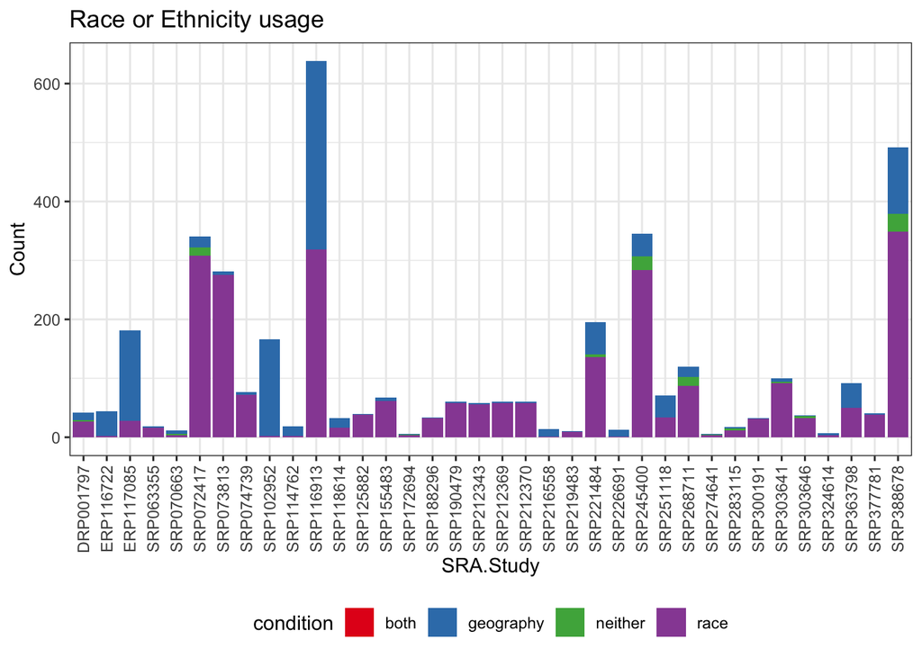

```r
tabulateTerms <- by(allSRAFinal[allSRAFinal$SRA.Study %in% conflictStudies,], allSRAFinal[allSRAFinal$SRA.Study %in% conflictStudies,]$SRA.Study, function(x) table(is.na(x$finalGeography), is.na(x$finalRace))) # So there's often a clear skew towards one category, which should make solving these easier...

tabulateTerms <- data.frame(melt(unlist(tabulateTerms)))
tabulateTerms$condition <- rep(c("both", "race", "geography", "neither"), nrow(tabulateTerms)/4)
tabulateTerms$SRA.Study <- str_sub(rownames(tabulateTerms), end=-2)

ggplot(tabulateTerms, aes(x = SRA.Study, y = value, fill=condition)) +
  geom_bar(stat="identity") +
  theme_bw() +
  ggtitle("Race or Ethnicity usage") +
  # xlab("finalSystem") +
  ylab("Count") +
  scale_fill_brewer(palette = "Set1") +
  theme(axis.text.x = element_text(angle = 90, vjust = 0.5, hjust=1)) +
  theme(legend.position="bottom")
```

From this it’s very clear what we should do for most studies! The vast majority of them should use only racial terms and (I’m guessing), swap Asian over to a racial descriptor. But anyhow, let’s manually spot check some of these:

```r
columnsILike <- c(1,10, 15, 34:36) # Just need those two intermediate ones tbh

by(allSRAFinal[allSRAFinal$SRA.Study %in% conflictStudies,], allSRAFinal[allSRAFinal$SRA.Study %in% conflictStudies,]$SRA.Study, function(x) head(x[,columnsILike]))
```

```
## allSRAFinal[allSRAFinal$SRA.Study %in% conflictStudies, ]$SRA.Study: DRP001797
##       SRA.Study ETHNICITY RACE finalRace                finalGeography hispanic
## 98154 DRP001797    Arabic <NA>      <NA> North Africa and Western Asia     <NA>
## 98176 DRP001797    Arabic <NA>      <NA> North Africa and Western Asia     <NA>
## 98300 DRP001797    Arabic <NA>      <NA> North Africa and Western Asia     <NA>
## 98394 DRP001797  Japanese <NA>      <NA>                     East Asia     <NA>
## 98440 DRP001797  Japanese <NA>      <NA>                     East Asia     <NA>
## 98443 DRP001797  Japanese <NA>      <NA>                     East Asia     <NA>
## ------------------------------------------------------------
## allSRAFinal[allSRAFinal$SRA.Study %in% conflictStudies, ]$SRA.Study: ERP116722
##        SRA.Study ETHNICITY RACE finalRace    finalGeography hispanic
## 188456 ERP116722  Mandingo <NA>      <NA> Subsaharan Africa     <NA>
## 188457 ERP116722      Jola <NA>      <NA> Subsaharan Africa     <NA>
## 188459 ERP116722  Mandingo <NA>      <NA> Subsaharan Africa     <NA>
## 188460 ERP116722     Fulla <NA>      <NA> Subsaharan Africa     <NA>
```

[output cut: 434 more lines]

```r
by(allSRAFinal[allSRAFinal$SRA.Study %in% conflictStudies,], allSRAFinal[allSRAFinal$SRA.Study %in% conflictStudies,]$SRA.Study, function(x) table(x$RACE))
```

```
## allSRAFinal[allSRAFinal$SRA.Study %in% conflictStudies, ]$SRA.Study: DRP001797
## < table of extent 0 >
## ------------------------------------------------------------
## allSRAFinal[allSRAFinal$SRA.Study %in% conflictStudies, ]$SRA.Study: ERP116722
## < table of extent 0 >
## ------------------------------------------------------------
## allSRAFinal[allSRAFinal$SRA.Study %in% conflictStudies, ]$SRA.Study: ERP117085
## < table of extent 0 >
## ------------------------------------------------------------
## allSRAFinal[allSRAFinal$SRA.Study %in% conflictStudies, ]$SRA.Study: SRP063355
## < table of extent 0 >
## ------------------------------------------------------------
## allSRAFinal[allSRAFinal$SRA.Study %in% conflictStudies, ]$SRA.Study: SRP070663
## < table of extent 0 >
## ------------------------------------------------------------
## allSRAFinal[allSRAFinal$SRA.Study %in% conflictStudies, ]$SRA.Study: SRP072417
##
## African American            Asian         Hispanic      South Asian
##               20               36               14               19
##            White   White.Hispanic
##              250                2
## ------------------------------------------------------------
## allSRAFinal[allSRAFinal$SRA.Study %in% conflictStudies, ]$SRA.Study: SRP073813
## < table of extent 0 >
## ------------------------------------------------------------
## allSRAFinal[allSRAFinal$SRA.Study %in% conflictStudies, ]$SRA.Study: SRP074739
## < table of extent 0 >
## ------------------------------------------------------------
## allSRAFinal[allSRAFinal$SRA.Study %in% conflictStudies, ]$SRA.Study: SRP102952
##
##  Bruneian Caucasian   Chinese    Indian     Malay
##         2         2       106        24        32
## ------------------------------------------------------------
## allSRAFinal[allSRAFinal$SRA.Study %in% conflictStudies, ]$SRA.Study: SRP114762
## < table of extent 0 >
## ------------------------------------------------------------
## allSRAFinal[allSRAFinal$SRA.Study %in% conflictStudies, ]$SRA.Study: SRP116913
## < table of extent 0 >
## ------------------------------------------------------------
## allSRAFinal[allSRAFinal$SRA.Study %in% conflictStudies, ]$SRA.Study: SRP118614
```

[output cut: 76 more lines]

```
##               23                1                1                1
##         Hispanic           Indian            White
##                3                1                7
## ------------------------------------------------------------
## allSRAFinal[allSRAFinal$SRA.Study %in% conflictStudies, ]$SRA.Study: SRP324614
## < table of extent 0 >
## ------------------------------------------------------------
## allSRAFinal[allSRAFinal$SRA.Study %in% conflictStudies, ]$SRA.Study: SRP363798
## < table of extent 0 >
## ------------------------------------------------------------
## allSRAFinal[allSRAFinal$SRA.Study %in% conflictStudies, ]$SRA.Study: SRP377781
## < table of extent 0 >
## ------------------------------------------------------------
## allSRAFinal[allSRAFinal$SRA.Study %in% conflictStudies, ]$SRA.Study: SRP388678
## < table of extent 0 >
```

```r
by(allSRAFinal[allSRAFinal$SRA.Study %in% conflictStudies,], allSRAFinal[allSRAFinal$SRA.Study %in% conflictStudies,]$SRA.Study, function(x) table(x$ETHNICITY))
```

```
## allSRAFinal[allSRAFinal$SRA.Study %in% conflictStudies, ]$SRA.Study: DRP001797
##
## African american           Arabic        Caucasian         Hispanic
##                8                3               19                2
##         Japanese
##               10
## ------------------------------------------------------------
## allSRAFinal[allSRAFinal$SRA.Study %in% conflictStudies, ]$SRA.Study: ERP116722
##
##    Fulla     Jola Mandingo  Manjago    Other   Wollof
##       14        7       15        2        2        4
## ------------------------------------------------------------
## allSRAFinal[allSRAFinal$SRA.Study %in% conflictStudies, ]$SRA.Study: ERP117085
##
##          black mixed ancestry
##             28            153
## ------------------------------------------------------------
## allSRAFinal[allSRAFinal$SRA.Study %in% conflictStudies, ]$SRA.Study: SRP063355
##
## asian black white
##     2     5    11
## ------------------------------------------------------------
## allSRAFinal[allSRAFinal$SRA.Study %in% conflictStudies, ]$SRA.Study: SRP070663
##
## African-American            Asian  Hispanic-Latino
##                3                6                3
## ------------------------------------------------------------
## allSRAFinal[allSRAFinal$SRA.Study %in% conflictStudies, ]$SRA.Study: SRP072417
## < table of extent 0 >
## ------------------------------------------------------------
## allSRAFinal[allSRAFinal$SRA.Study %in% conflictStudies, ]$SRA.Study: SRP073813
##
## African American            Asian        Caucasian            Other
##                6                6              260                6
## Pacific Islander
##                3
## ------------------------------------------------------------
## allSRAFinal[allSRAFinal$SRA.Study %in% conflictStudies, ]$SRA.Study: SRP074739
##
## Africa American       Caucasian    South Indian
```

[output cut: 130 more lines]

```
##                               2                               2
## ------------------------------------------------------------
## allSRAFinal[allSRAFinal$SRA.Study %in% conflictStudies, ]$SRA.Study: SRP377781
##
##     asian caucasian     mixed
##         2        38         1
## ------------------------------------------------------------
## allSRAFinal[allSRAFinal$SRA.Study %in% conflictStudies, ]$SRA.Study: SRP388678
##
## African American/Black       Ashkenazi Jewish                  Asian
##                     42                     12                     66
##              Caucasian               Hispanic         Middle Eastern
##                    305                     30                      9
##        Mixed Ethnicity                  Other
##                     26                      2
```

On the basis of that, studies with info originally in the race column: 1. *SRP072417*: Racial but distinguishes between South Asian and Asian (should just collapse.) 1. *SRP102952*: Caucasian when the rest is clearly from ISEA, should be geography. 1. SRP188296: Single Arabic individual 1. SRP219483: Single Asian Indian indivual, but distinguishes between African American and Black (sigh) 1. SRP226691: Single Caucasian and a lot of Japanese? 1. *SRP268711*: Asian (Nepali) should be race:Asian? 1. SRP300191: Eastern African distinct from African American 1. SRP303646: single Indian individual (and two ways of mispelling Caucasian)

And now the flip side (bolded are updated below): 1. DRP001797: Mixture of terms - Arabic, Japanese, and census terms. 1. *ERP116722*: Distinct African groups and ‘other’ which is getting parsed incorrectly. Should be all geography. 1. ERP117085: Black vs mixed geography; comes from UCL so would move 100% to ethnicity 1. *SRP063355*: Should be all race. 1. *SRP070663*: Should be all race. 1. *SRP073813*: Should be all race. 1. SRP074739: 5 South Indian inds, not clear. 1. SRP114762: Black and white… should keep it consistent not matter what. 1. *SRP116913*: Should be all race. 1. SRP118614: IDEK 1. SRP125882: IDEK 1. SRP172694, SRP274641: Should be race minus the hispanic sample - AsianPacific Islander is messing things up, should be Pacific islander. **This one is annoying to fix, so doing it later** 1. SRP190479, SRP212343, SRP212369, SRP212370: Middle Eastern keeping it from being race. 1. SRP216558: IDEK 1. *SRP245400*: Should be all race minus the hispanic. 1. *SRP251118*: Probably race. 1. SRP283115: AsianPacific should probably be Pacific Islander. **This one is annoying to fix, so doing it later** 1. SRP303641: North African otherwise race/hispanic. 1. *SRP324614*: Should be race. 1. SRP363798: Caucasian should go to Europe? 1. SRP377781: IDEK 1. SRP388678: IDEK

Some of the easier fixes, implemented here (should probably do it before, but let’s wait for a reply to my email first). Annoying to do it manually, but here we are.

```r
# I don't trust the ordering to be maintained...
allSRAFinal[allSRAFinal$SRA.Study %in% c("ERP116722", "SRP102952"), ]$finalGeography <- coalesce(allSRAFinal[allSRAFinal$SRA.Study %in% c("ERP116722", "SRP102952"), ]$finalGeography, allSRAFinal[allSRAFinal$SRA.Study %in% c("ERP116722", "SRP102952"), ]$finalRace)

allSRAFinal[allSRAFinal$SRA.Study %in% c("SRP063355", "SRP070663", "SRP073813", "SRP116913", "SRP245400", "SRP251118", "SRP324614", "SRP268711", "SRP072417"), ]$finalRace <- coalesce(allSRAFinal[allSRAFinal$SRA.Study %in% c("SRP063355", "SRP070663", "SRP073813", "SRP116913", "SRP245400", "SRP251118", "SRP324614", "SRP268711", "SRP072417"), ]$finalRace, allSRAFinal[allSRAFinal$SRA.Study %in% c("SRP063355", "SRP070663", "SRP073813", "SRP116913", "SRP245400", "SRP251118", "SRP324614", "SRP268711", "SRP072417"), ]$finalGeography)

# Seems like ordering is maintained, so...
table(allSRAFinal$finalGeography)
```

```
##
##                      Americas                          Asia
##                           164                           304
##                     East Asia                        Europe
##                          1333                          3281
##                      Multiple North Africa and Western Asia
##                           206                            27
##                         Other                    South Asia
##                             3                           773
##                Southeast Asia             Subsaharan Africa
##                            83                           524
##                         White
##                             2
```

```r
table(allSRAFinal$finalRace)
```

```
##
##         American Indian or Alaskan Native
##                                        83
##                                      Asia
##                                        52
##                                     Asian
##                                       658
##                 Black or African American
##                                      2993
##                                    Europe
##                                       346
##                                  Multiple
##                                       244
## Native Hawaiian or other Pacific Islander
##                                        19
##                                     Other
##                                       278
##                                South Asia
##                                        51
##                                     White
##                                     12538
```

```r
# and now we need to update some the terms that have changed:
allSRAFinal$finalGeography <- gsub("White", "Europe", allSRAFinal$finalGeography)
allSRAFinal$finalRace <- gsub("South Asia", "Asian", allSRAFinal$finalRace) %>% gsub("Europe", "White", .) %>% gsub("Asia$", "Asian", .) %>% gsub("Subsaharan Africa", "Black or African American", .)

# And set the other descriptor to NA:
allSRAFinal[allSRAFinal$SRA.Study %in% c("ERP116722", "SRP102952"), ]$finalRace <- NA
allSRAFinal[allSRAFinal$SRA.Study %in% c("SRP063355", "SRP070663", "SRP073813", "SRP116913", "SRP245400", "SRP251118", "SRP324614", "SRP268711", "SRP072417"), ]$finalGeography <- NA

# And now let's make the plot again to see if things have improved:
tabulatePops2 <- by(allSRAFinal, allSRAFinal$SRA.Study, function(x) table(x$finalGeography, x$finalRace))
conflictStudies2 <- names(tabulatePops2[lapply(tabulatePops2, function(x) grep("NULL", dimnames(x))) %>% grepl(0, .)])
length(conflictStudies2)
```

```
## [1] 25
```

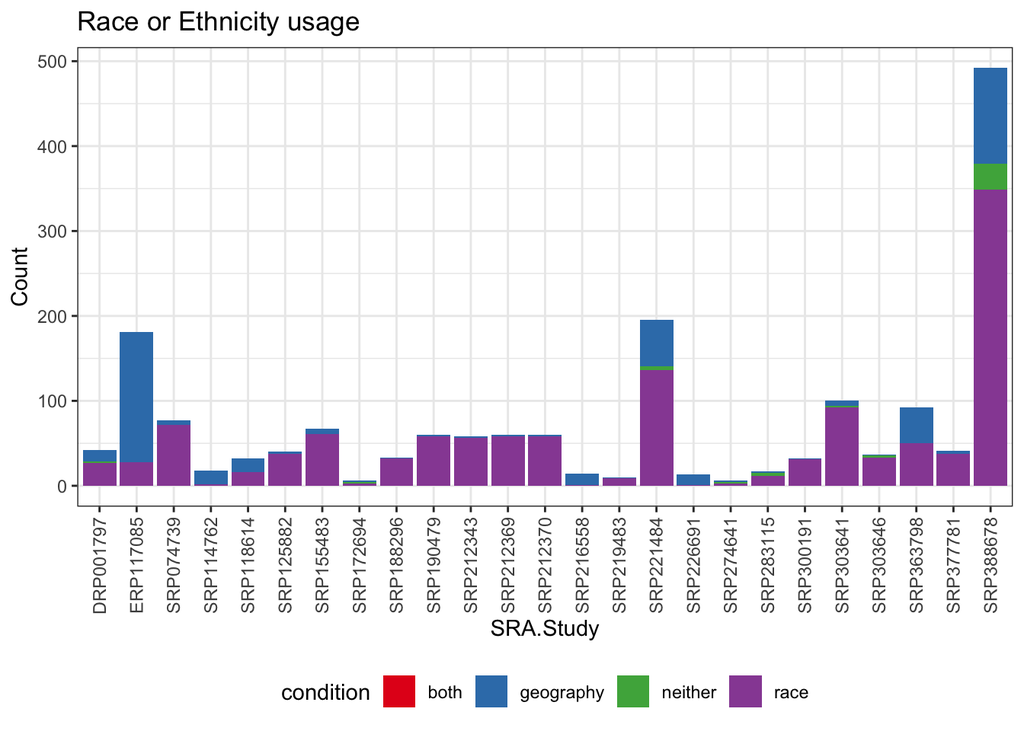

```r
tabulateTerms2 <- by(allSRAFinal[allSRAFinal$SRA.Study %in% conflictStudies2,], allSRAFinal[allSRAFinal$SRA.Study %in% conflictStudies2,]$SRA.Study, function(x) table(is.na(x$finalGeography), is.na(x$finalRace))) # So there's often a clear skew towards one category, which should make solving these easier...

tabulateTerms2 <- data.frame(melt(unlist(tabulateTerms2)))
tabulateTerms2$condition <- rep(c("both", "race", "geography", "neither"), nrow(tabulateTerms2)/4)
tabulateTerms2$SRA.Study <- str_sub(rownames(tabulateTerms2), end=-2)

ggplot(tabulateTerms2, aes(x = SRA.Study, y = value, fill=condition)) +
  geom_bar(stat="identity") +
  theme_bw() +
  ggtitle("Race or Ethnicity usage") +
  # xlab("finalSystem") +
  ylab("Count") +
  scale_fill_brewer(palette = "Set1") +
  theme(axis.text.x = element_text(angle = 90, vjust = 0.5, hjust=1)) +
  theme(legend.position="bottom")
```

Basic plots of population descriptors, now that we’re happy with that.

```r
sampleGeography <- allSRAFinal %>% count(SRA.Study, finalGeography) %>% drop_na(finalGeography)
sampleRace <- allSRAFinal %>% count(SRA.Study, finalRace) %>% drop_na(finalRace)
meltSampleGeography <- melt(sampleGeography)
meltSampleRace <- melt(sampleRace)
table(allSRAFinal$finalGeography)
```

```
##
##                      Americas                          Asia
##                           164                           252
##                     East Asia                        Europe
##                          1333                          2937
##                      Multiple North Africa and Western Asia
##                           206                            27
##                         Other                    South Asia
##                             3                           722
##                Southeast Asia             Subsaharan Africa
##                            83                           524
```

```r
table(allSRAFinal$finalRace)
```

```
##
##         American Indian or Alaskan Native
##                                        83
##                                     Asian
##                                       761
##                 Black or African American
##                                      2993
##                                  Multiple
##                                       244
## Native Hawaiian or other Pacific Islander
##                                        19
##                                     Other
##                                       276
##                                     White
##                                     12882
```

```r
sum(table(allSRAFinal$finalGeography))
```

```
## [1] 6251
```

```r
sum(table(allSRAFinal$finalRace))
```

```
## [1] 17258
```

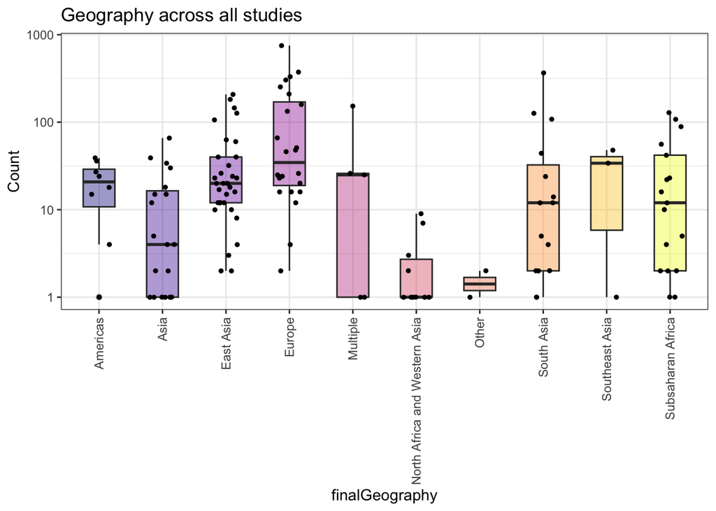

```r
ggplot(meltSampleGeography, aes(x = finalGeography, y=value,fill=finalGeography)) +
  geom_boxplot(width=0.5, alpha=0.4) +
  geom_jitter(size=1, width=0.2) +
  theme_bw() +
  ggtitle("Geography across all studies") +
  # xlab("System") +
  ylab("Count") +
  scale_y_continuous(trans='log10') +
  scale_fill_viridis(discrete=T, na.value="grey50", option="plasma") +
  theme(axis.text.x = element_text(angle = 90, vjust = 0.5, hjust=1)) +
  theme(legend.position = "none")
```

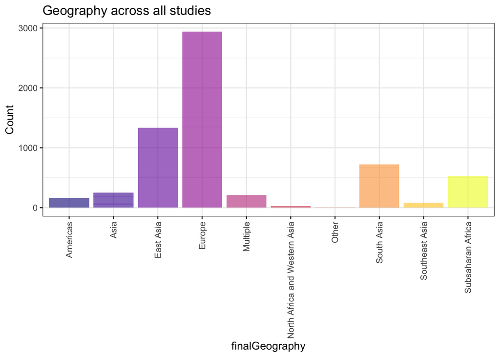

```r
ggplot(meltSampleGeography, aes(x = finalGeography, y=value,fill=finalGeography)) +
  geom_bar(stat="identity", alpha=0.6) +
  theme_bw() +
  ggtitle("Geography across all studies") +
  # xlab("System") +
  ylab("Count") +
  # scale_y_continuous(trans='log10') +
  scale_fill_viridis(discrete=T, na.value="grey50", option="plasma") +
  theme(axis.text.x = element_text(angle = 90, vjust = 0.5, hjust=1)) +
  theme(legend.position = "none")
```

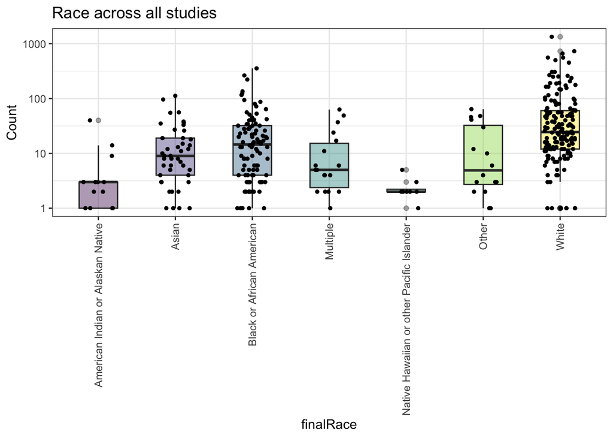

```r
ggplot(meltSampleRace, aes(x = finalRace, y=value,fill=finalRace)) +
  geom_boxplot(width=0.5, alpha=0.4) +
  geom_jitter(size=1, width=0.2) +
  theme_bw() +
  ggtitle("Race across all studies") +
  # xlab("System") +
  ylab("Count") +
  scale_y_continuous(trans='log10') +
  scale_fill_viridis(discrete=T, na.value="grey50") +
  theme(axis.text.x = element_text(angle = 90, vjust = 0.5, hjust=1)) +
  theme(legend.position = "none")
```

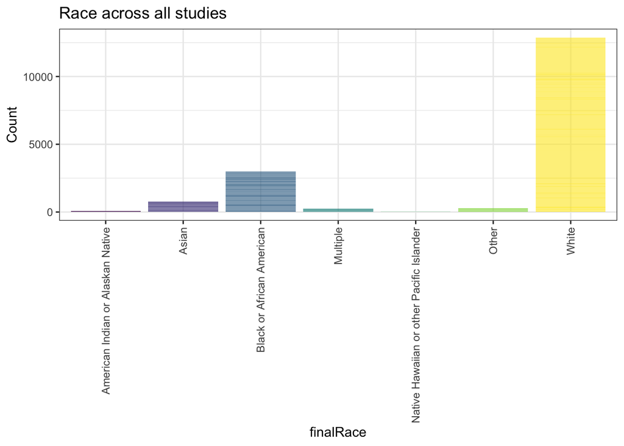

```r
ggplot(meltSampleRace, aes(x = finalRace, y=value,fill=finalRace)) +
  geom_bar(stat="identity", alpha=0.6) +
  theme_bw() +
  ggtitle("Race across all studies") +
  # xlab("System") +
  ylab("Count") +
  # scale_y_continuous(trans='log10') +
  scale_fill_viridis(discrete=T, na.value="grey50") +
  theme(axis.text.x = element_text(angle = 90, vjust = 0.5, hjust=1)) +
  theme(legend.position = "none")
```

Yeah that looks good enough. At this point it might be interesting to see where the studies are coming from… but that is harder to parse than you might expect, so we’ll save that for later.

First, some summary statistics and plots:

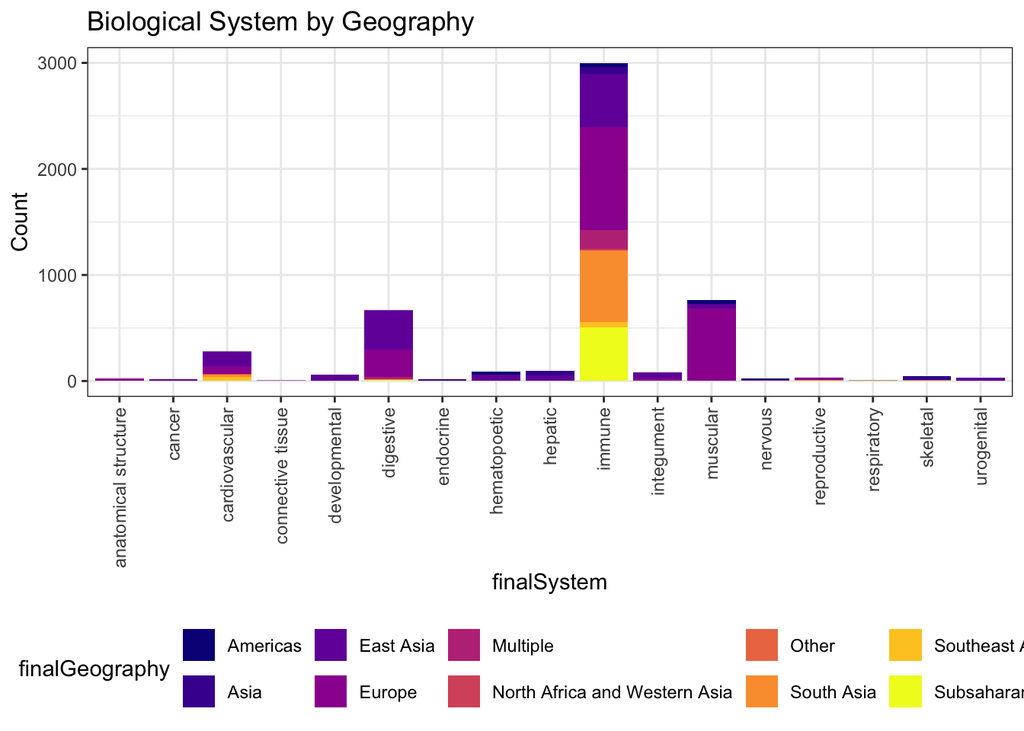

```r
# First we focus on population descriptors:
bigGeographySummary <- allSRAFinal %>% count(SRA.Study, finalGeography, finalSystem, finalOrgan)
bigRaceSummary <- allSRAFinal %>% count(SRA.Study, finalRace, finalSystem, finalOrgan)
GeographySummary <- allSRAFinal %>% count(finalGeography, finalSystem, finalOrgan)
raceSummary <- allSRAFinal %>% count(finalRace, finalSystem, finalOrgan)

meltGeography <- melt(GeographySummary)
meltRace <- melt(raceSummary)
meltGeography %>% drop_na(c(finalSystem, finalGeography)) %>%
  ggplot(., aes(x = finalSystem, y=value, fill=finalGeography)) +
    geom_bar(stat="identity") +
    ggtitle("Biological System by Geography") +
    # xlab("finalSystem") +
    ylab("Count") +
    theme_bw() +
    scale_fill_viridis(discrete=T, na.value="grey50", option="plasma") +
    theme(axis.text.x = element_text(angle = 90, vjust = 0.5, hjust=1)) +
    theme(legend.position="bottom")
```

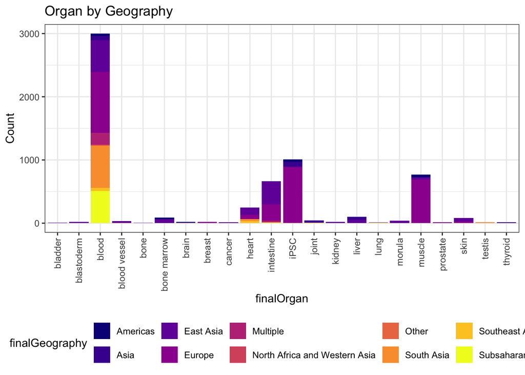

```r
meltGeography %>% drop_na(c(finalOrgan, finalGeography)) %>%
  ggplot(., aes(x = finalOrgan, y= value, fill=finalGeography)) +
    geom_bar(stat="identity") +
    theme_bw() +
    ggtitle("Organ by Geography") +
    # xlab("finalOrgan") +
    ylab("Count") +
    scale_fill_viridis(discrete=T, na.value="grey50", option="plasma") +
    theme(axis.text.x = element_text(angle = 90, vjust = 0.5, hjust=1)) +
    theme(legend.position="bottom")
```

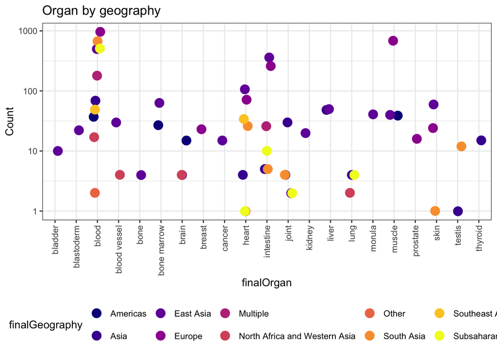

```r
meltGeography %>% drop_na(c(finalOrgan, finalSystem, finalGeography)) %>%
ggplot(., aes(x = finalOrgan, y= value, color=finalGeography, fill=finalGeography)) +
  geom_jitter(size = 4, width=0.2) +
  theme_bw() +
  ggtitle("Organ by geography") +
  # xlab("Organ") +
  ylab("Count") +
  scale_y_continuous(trans='log10') +
  scale_color_viridis(discrete=T, na.value="grey50", option="plasma") +
  theme(axis.text.x = element_text(angle = 90, vjust = 0.5, hjust=1)) +
  theme(legend.position = "bottom")
```

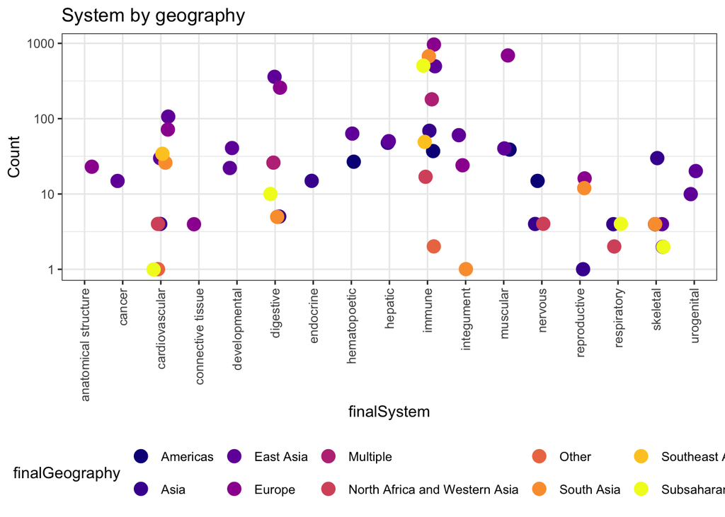

```r
meltGeography %>% drop_na(c(finalSystem, finalGeography)) %>%
ggplot(., aes(x = finalSystem, y= value, color=finalGeography, fill=finalGeography)) +
  geom_jitter(size = 4, width=0.2) +
  theme_bw() +
  ggtitle("System by geography") +
  # xlab("System") +
  ylab("Count") +
  scale_y_continuous(trans='log10') +
  scale_color_viridis(discrete=T, na.value="grey50", option="plasma") +
  theme(axis.text.x = element_text(angle = 90, vjust = 0.5, hjust=1)) +
  theme(legend.position = "bottom")
```

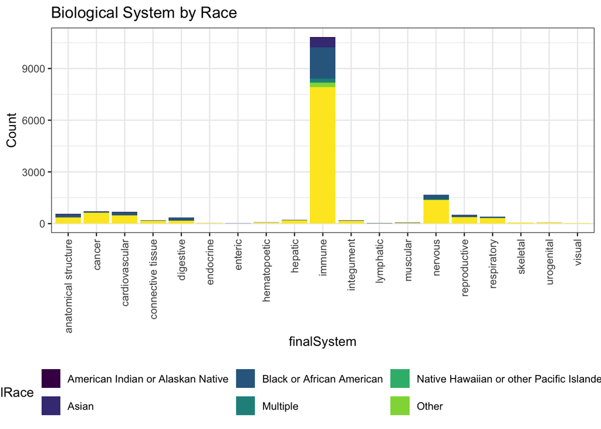

```r
meltRace %>% drop_na(c(finalSystem, finalRace)) %>%
  ggplot(., aes(x = finalSystem, y= value, fill=finalRace)) +
    geom_bar(stat="identity") +
    theme_bw() +
    ggtitle("Biological System by Race") +
    # xlab("finalSystem") +
    ylab("Count") +
    scale_fill_viridis(discrete=T, na.value="grey50") +
    theme(axis.text.x = element_text(angle = 90, vjust = 0.5, hjust=1)) +
    theme(legend.position="bottom")
```

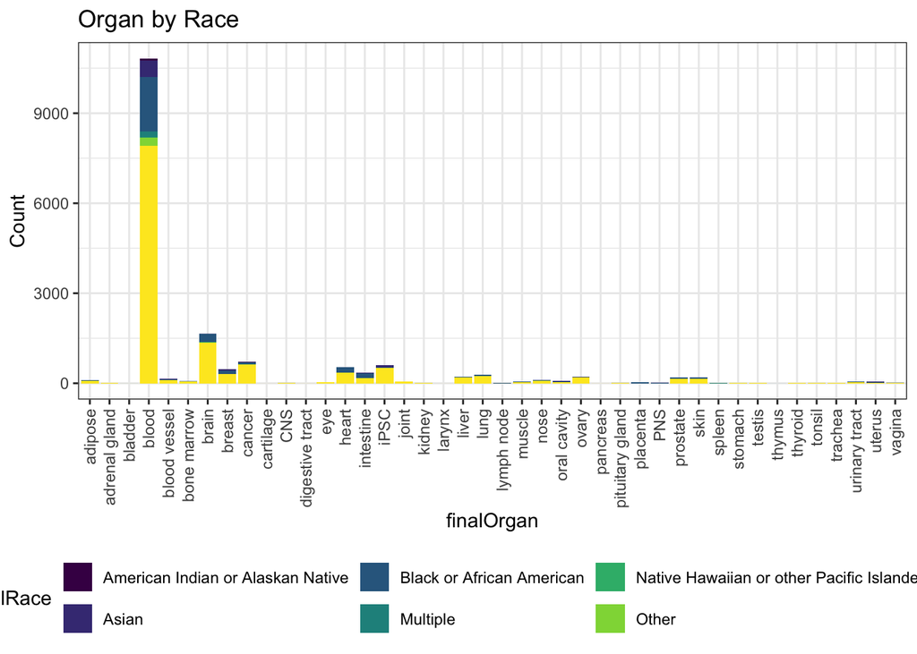

```r
meltRace %>% drop_na(c(finalOrgan, finalRace)) %>%
  ggplot(., aes(x = finalOrgan, y= value, fill=finalRace)) +
    geom_bar(stat="identity") +
    theme_bw() +
    ggtitle("Organ by Race") +
    # xlab("finalSystem") +
    ylab("Count") +
    scale_fill_viridis(discrete=T, na.value="grey50") +
    theme(axis.text.x = element_text(angle = 90, vjust = 0.5, hjust=1)) +
    theme(legend.position="bottom")
```

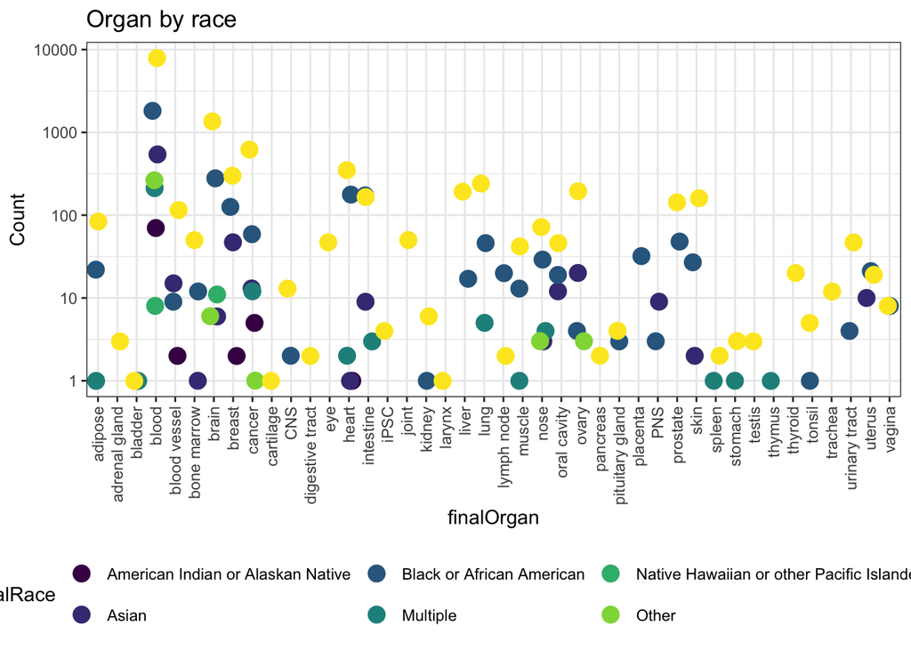

```r
meltRace %>% drop_na(c(finalOrgan, finalSystem, finalRace)) %>%
ggplot(., aes(x = finalOrgan, y= value, color=finalRace, fill=finalRace)) +
  geom_jitter(size = 4, width=0.2) +
  theme_bw() +
  ggtitle("Organ by race") +
  # xlab("Organ") +
  ylab("Count") +
  scale_y_continuous(trans='log10') +
  scale_color_viridis(discrete=T, na.value="grey50") +
  theme(axis.text.x = element_text(angle = 90, vjust = 0.5, hjust=1)) +
  theme(legend.position = "bottom")
```

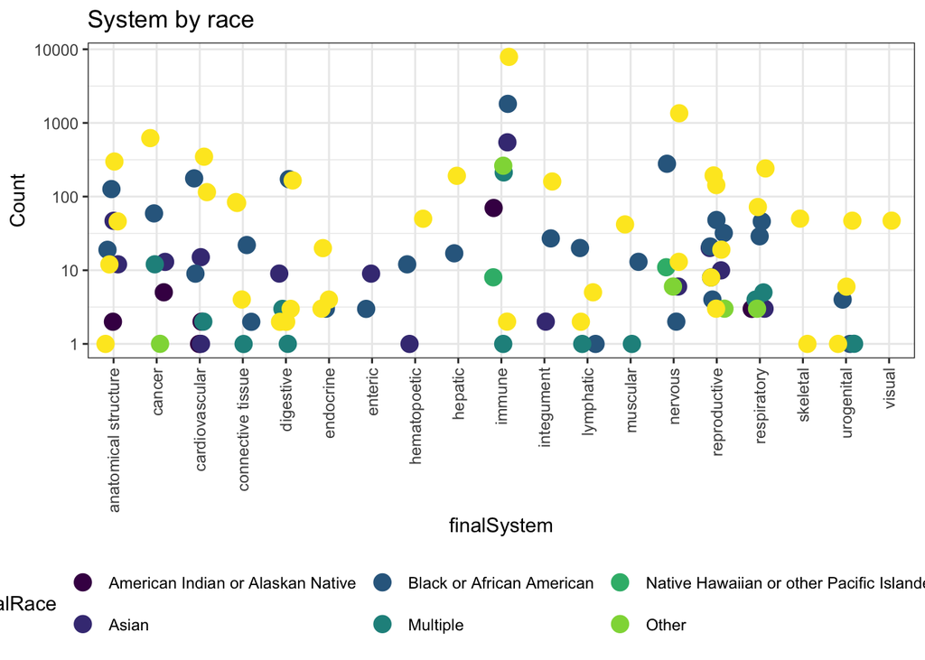

```r
meltRace %>% drop_na(c(finalSystem, finalRace)) %>%
ggplot(., aes(x = finalSystem, y= value, color=finalRace, fill=finalRace)) +
  geom_jitter(size = 4, width=0.2) +
  theme_bw() +
  ggtitle("System by race") +
  # xlab("System") +
  ylab("Count") +
  scale_y_continuous(trans='log10') +
  scale_color_viridis(discrete=T, na.value="grey50") +
  theme(axis.text.x = element_text(angle = 90, vjust = 0.5, hjust=1)) +
  theme(legend.position = "bottom")
```

We’re also interested in how diverse a given study is, and how many studies include samples from each descriptor. We can easily calculate all of that too, although it is hard to see visually.

```r
geographyStudy <- allSRAFinal %>% count(SRA.Study, finalGeography) %>% drop_na(finalGeography)

# How many studies with any sort of Geography info?
dim(geographyStudy)
```

```
## [1] 136   3
```

```r
length(unique(geographyStudy$SRA.Study))
```

```
## [1] 94
```

```r
# And some quick stats on diversity by study:
geographyStudy %>% count(SRA.Study) %>% summary()
```

```
##   SRA.Study               n
##  Length:94          Min.   :1.000
##  Class :character   1st Qu.:1.000
##  Mode  :character   Median :1.000
##                     Mean   :1.447
##                     3rd Qu.:1.750
##                     Max.   :5.000
```

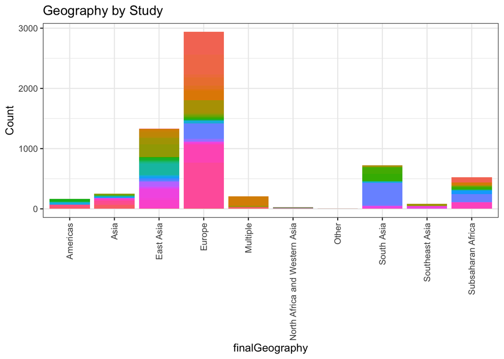

```r
# But... how many samples?
ggplot(geographyStudy, aes(x = finalGeography, y=n, fill=SRA.Study)) +
  geom_bar(stat="identity") +
  ggtitle("Geography by Study") +
  ylab("Count") +
  theme_bw() +
  theme(axis.text.x = element_text(angle = 90, vjust = 0.5, hjust=1)) +
  theme(legend.position = "none")
```

```r
# This is hard to see, so:
ddply(geographyStudy, "finalGeography", summarise, totalN = sum(n), meanN=mean(n), maxN=max(n), nStudies=length(unique((SRA.Study))))
```

```
##                   finalGeography totalN     meanN maxN nStudies
## 1                       Americas    164  20.50000   39        8
## 2                           Asia    252  13.26316   66       19
## 3                      East Asia   1333  40.39394  208       33
## 4                         Europe   2937 122.37500  753       24
## 5                       Multiple    206  41.20000  153        5
## 6  North Africa and Western Asia     27   2.70000    9       10
## 7                          Other      3   1.50000    2        2
## 8                     South Asia    722  48.13333  365       15
## 9                 Southeast Asia     83  27.66667   48        3
## 10             Subsaharan Africa    524  30.82353  129       17
```

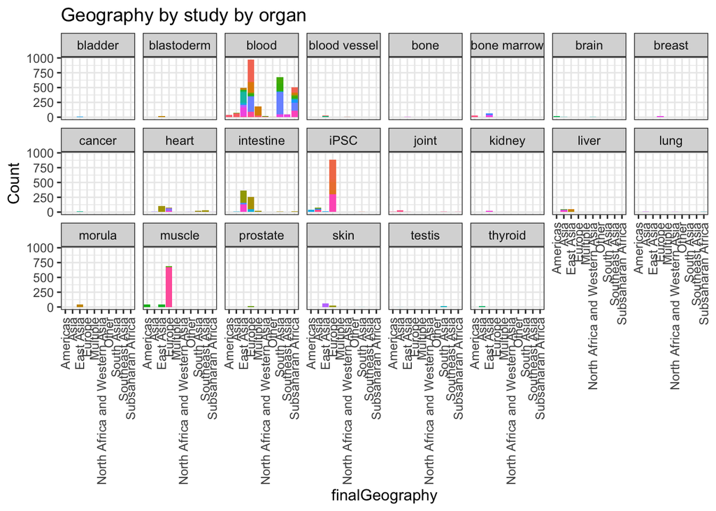

```r
# Now adding the finalOrgan dimension
geographyStudyfinalOrgan <- allSRAFinal %>% count(SRA.Study, finalGeography, finalOrgan) %>% drop_na(finalGeography, finalOrgan)

ggplot(geographyStudyfinalOrgan, aes(x = finalGeography, y=n, fill=SRA.Study)) +
  geom_bar(stat="identity") +
  facet_wrap( ~ finalOrgan, nrow=3) +
  ggtitle("Geography by study by organ") +
  ylab("Count") +
  theme_bw() +
  theme(axis.text.x = element_text(angle = 90, vjust = 0.5, hjust=1)) +
  theme(legend.position = "none")
```

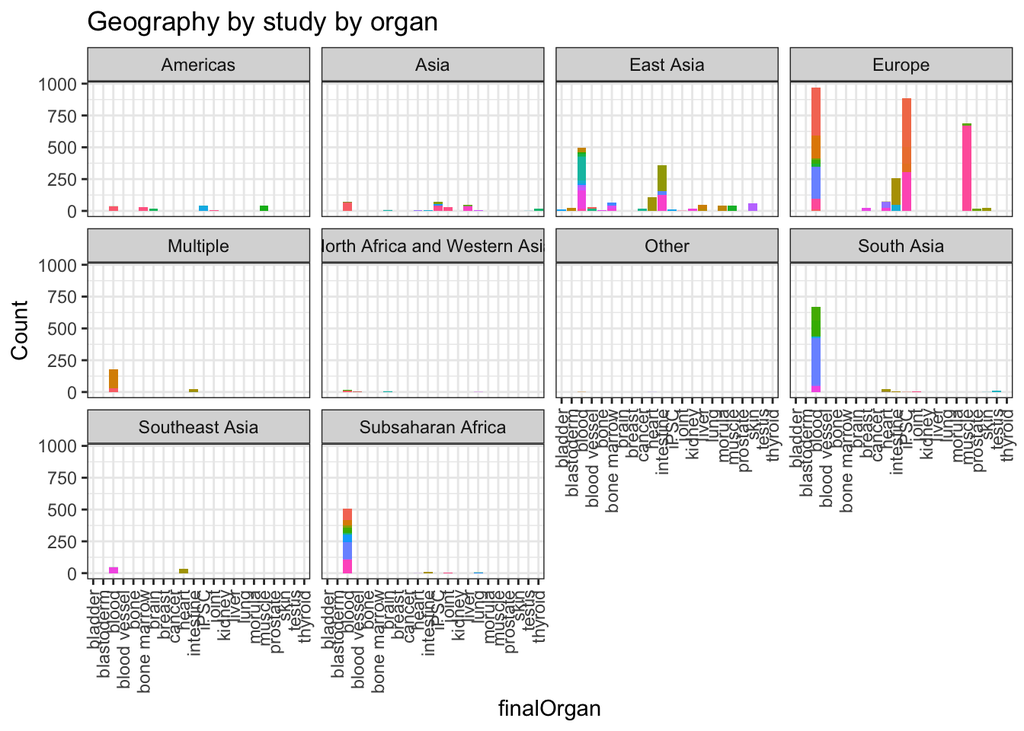

```r
ggplot(geographyStudyfinalOrgan, aes(x = finalOrgan, y=n, fill=SRA.Study)) +
  geom_bar(stat="identity") +
  facet_wrap( ~ finalGeography, nrow=3) +
  ggtitle("Geography by study by organ") +
  ylab("Count") +
  theme_bw() +
  theme(axis.text.x = element_text(angle = 90, vjust = 0.5, hjust=1)) +
  theme(legend.position = "none")
```

```r
# And now really broken down:
ddply(geographyStudyfinalOrgan, c("finalGeography", "finalOrgan"), summarise, totalN = sum(n), meanN=mean(n), maxN=max(n), nStudies=length(unique((SRA.Study))))
```

```
##                   finalGeography   finalOrgan totalN      meanN maxN nStudies
## 1                       Americas        blood     37  18.500000   36        2
## 2                       Americas  bone marrow     27  27.000000   27        1
## 3                       Americas        brain     15  15.000000   15        1
## 4                       Americas         iPSC     42  21.000000   24        2
## 5                       Americas        joint      4   4.000000    4        1
## 6                       Americas       muscle     39  39.000000   39        1
## 7                           Asia        blood     69  23.000000   66        3
## 8                           Asia        brain      4   1.000000    1        4
## 9                           Asia        heart      4   4.000000    4        1
## 10                          Asia    intestine      5   5.000000    5        1
## 11                          Asia         iPSC     72  24.000000   39        3
## 12                          Asia        joint     30  30.000000   30        1
## 13                          Asia        liver     48  16.000000   34        3
## 14                          Asia         lung      4   4.000000    4        1
```

[output cut: 48 more lines]

- SRP245400: Splicing profile by capture RNA-seq identifies pathogenic germline variants in tumor suppressor genes (Ambry Genetics)
- SRP333281: Intergrative Multi-Omics of Asian Pregnant Mother (Singapore)
- SRP333281: Intergrative Multi-Omics of Asian Pregnant Mother (Singapore)
- SRP237697: mRNA sequencing of 28 visceral leishmaniasis-HIV patients in NW-Ethiopia (pre-post treatment)
- SRP388678: Identification and interpretation of splicing variants using paired DNA and RNA sequencing in a clinical cohort of patients tested for hereditary cancer predisposition (Ambry Genetics)
- SRP358657: Local and finalSystemic transcriptomic responses from acute exercise induced muscle damage of the human knee extensor
- SRP126583: A modular transcriptional signature identifies phenotypic heterogeneity of human tuberculosis infection
- SRP126691: A modular transcriptional signature identifies phenotypic heterogeneity of human tuberculosis infection
- SRP333281: Intergrative Multi-Omics of Asian Pregnant Mother (Singapore)
- SRP200298: Transcriptome and methylome of human suicide attempter and major depressive disorder patient (Korea)

These make sense! The Singaporean cohorts will be the three main Geography: (South) Chinese, Malay and Tamil; Ambry is of course invested in diversity, TB is unlikely to show up in Europe. Also I am willing to bet any amount of money that the digestive Asian sequencing comes from cancer samples too somehow?

Anyhow, now we do the same for race:

```r
raceStudy <- allSRAFinal %>% count(SRA.Study, finalRace) %>% drop_na(finalRace)

# How many studies with any sort of Race info?
dim(raceStudy)
```

```
## [1] 368   3
```

```r
length(unique(raceStudy$SRA.Study))
```

```
## [1] 190
```

```r
# And some quick stats on diversity by study:
raceStudy %>% count(SRA.Study) %>% summary()
```

```
##   SRA.Study               n
##  Length:190         Min.   :1.000
##  Class :character   1st Qu.:1.000
##  Mode  :character   Median :2.000
##                     Mean   :1.937
##                     3rd Qu.:2.000
##                     Max.   :7.000
```

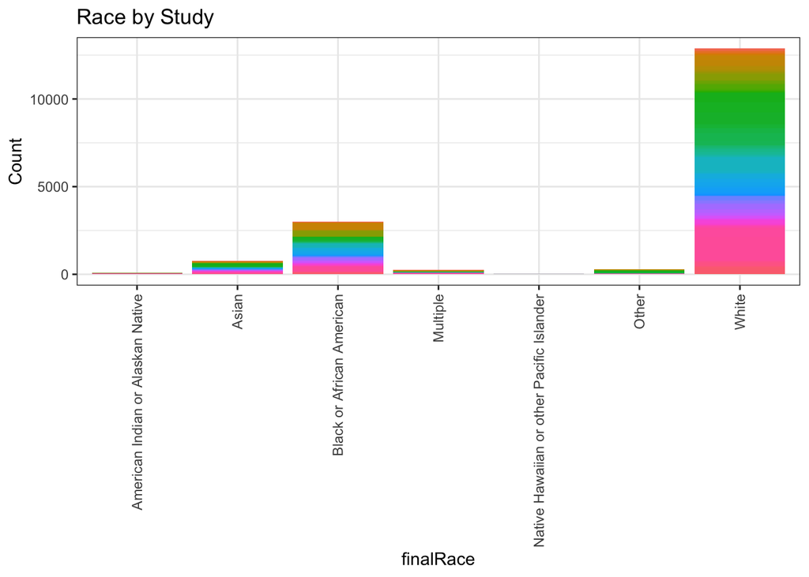

```r
# But... how many samples?
ggplot(raceStudy, aes(x = finalRace, y=n, fill=SRA.Study)) +
  geom_bar(stat="identity") +
  ggtitle("Race by Study") +
  ylab("Count") +
  theme_bw() +
  theme(axis.text.x = element_text(angle = 90, vjust = 0.5, hjust=1)) +
  theme(legend.position = "none")
```

```r
# This is hard to see, so:
ddply(raceStudy, "finalRace", summarise, totalN = sum(n), meanN=mean(n), maxN=max(n), nStudies=length(unique((SRA.Study))))
```

```
##                                   finalRace totalN     meanN maxN nStudies
## 1         American Indian or Alaskan Native     83  6.384615   40       13
## 2                                     Asian    761 17.697674  112       43
## 3                 Black or African American   2993 29.930000  355      100
## 4                                  Multiple    244 13.555556   63       18
## 5 Native Hawaiian or other Pacific Islander     19  2.375000    5        8
## 6                                     Other    276 17.250000   64       16
## 7                                     White  12882 75.776471 1337      170
```

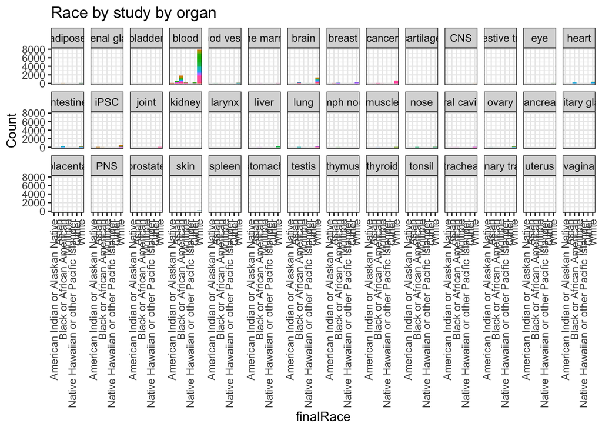

```r
# Now adding the finalOrgan dimension
raceStudyfinalOrgan <- allSRAFinal %>% count(SRA.Study, finalRace, finalOrgan) %>% drop_na(finalRace, finalOrgan)

ggplot(raceStudyfinalOrgan, aes(x = finalRace, y=n, fill=SRA.Study)) +
  geom_bar(stat="identity") +
  facet_wrap( ~ finalOrgan, nrow=3) +
  ggtitle("Race by study by organ") +
  ylab("Count") +
  theme_bw() +
  theme(axis.text.x = element_text(angle = 90, vjust = 0.5, hjust=1)) +
  theme(legend.position = "none")
```

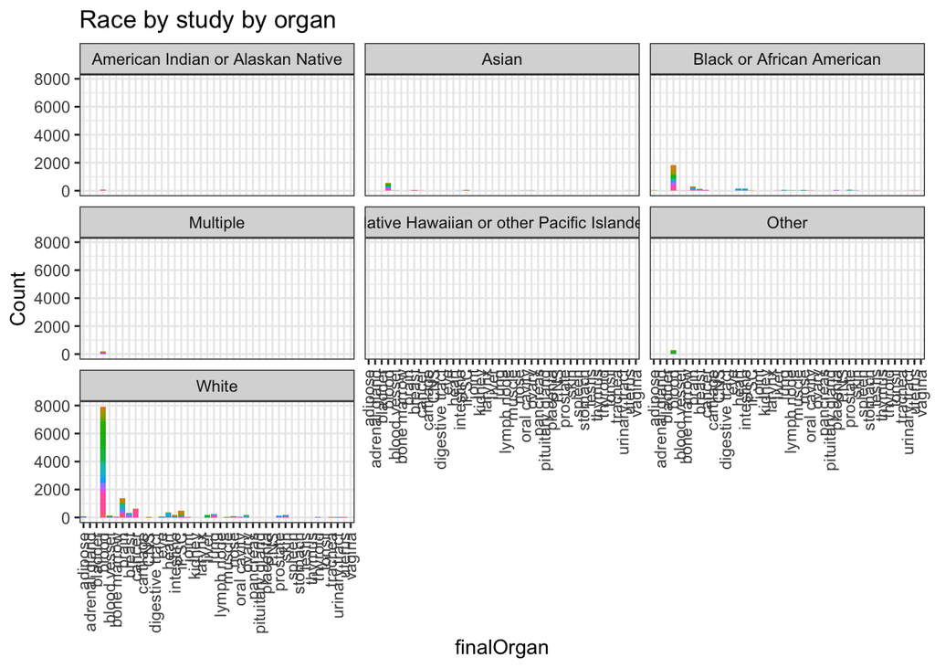

```r
ggplot(raceStudyfinalOrgan, aes(x = finalOrgan, y=n, fill=SRA.Study)) +
  geom_bar(stat="identity") +
  facet_wrap( ~ finalRace, nrow=3) +
  ggtitle("Race by study by organ") +
  ylab("Count") +
  theme_bw() +
  theme(axis.text.x = element_text(angle = 90, vjust = 0.5, hjust=1)) +
  theme(legend.position = "none")
```

```r
# And now really broken down:
ddply(raceStudyfinalOrgan, c("finalRace", "finalOrgan"), summarise, totalN = sum(n), meanN=mean(n), maxN=max(n), nStudies=length(unique((SRA.Study))))
```

```
##                                     finalRace      finalOrgan totalN      meanN
## 1           American Indian or Alaskan Native           blood     70  10.000000
## 2           American Indian or Alaskan Native    blood vessel      2   2.000000
## 3           American Indian or Alaskan Native          breast      2   1.000000
## 4           American Indian or Alaskan Native          cancer      5   2.500000
## 5           American Indian or Alaskan Native           heart      1   1.000000
## 6           American Indian or Alaskan Native            nose      3   3.000000
## 7                                       Asian           blood    544  22.666667
## 8                                       Asian    blood vessel     15  15.000000
## 9                                       Asian     bone marrow      1   1.000000
## 10                                      Asian           brain      6   6.000000
## 11                                      Asian          breast     47  15.666667
## 12                                      Asian          cancer     13  13.000000
## 13                                      Asian           heart      1   1.000000
## 14                                      Asian       intestine      9   9.000000
```

[output cut: 201 more lines]

Wowowowow the stark difference. Would be nice to slice this by country of sampling to see if this is really driven by the USA, or if random people are using race terms…